# Frequency Distributions and Visualization with R

Sara Geremia

2024-03-19

Load data

```r
load("practice/01-Descriptive/data/milan_egypop.RData")
```

```r
head(milan_egypop)
```

```
## # A tibble: 6 × 7
##   year  id_nil nil     age gender  nat    inhab
##   <fct> <fct>  <fct> <dbl> <fct>   <fct>  <dbl>
## 1 1999  1      Duomo     0 Femmine Egitto     1
## 2 1999  1      Duomo    10 Femmine Egitto     1
## 3 1999  1      Duomo    14 Femmine Egitto     1
## 4 1999  1      Duomo    15 Maschi  Egitto     1
## 5 1999  1      Duomo    17 Maschi  Egitto     1
## 6 1999  1      Duomo    20 Maschi  Egitto     1
```

```r
tail(milan_egypop)
```

```
## # A tibble: 6 × 7
##   year  id_nil nil                     age gender  nat    inhab
##   <fct> <fct>  <fct>                 <dbl> <fct>   <fct>  <dbl>
## 1 2023  88     Parco Bosco in citta'    18 Maschi  Egitto     1
## 2 2023  88     Parco Bosco in citta'    20 Maschi  Egitto     2
## 3 2023  88     Parco Bosco in citta'    34 Maschi  Egitto     1
## 4 2023  88     Parco Bosco in citta'    38 Femmine Egitto     1
## 5 2023  88     Parco Bosco in citta'    47 Femmine Egitto     1
## 6 2023  88     Parco Bosco in citta'    52 Maschi  Egitto     1
```

The `str` function compactly display the internal structure of an R object, in this case a data frame.

```r
str(milan_egypop)
```

```
## spc_tbl_ [148,582 × 7] (S3: spec_tbl_df/tbl_df/tbl/data.frame)
##  $ year  : Factor w/ 25 levels "1999","2000",..: 1 1 1 1 1 1 1 1 1 1 ...
##  $ id_nil: Factor w/ 85 levels "1","2","4","5",..: 1 1 1 1 1 1 1 1 1 1 ...
##  $ nil   : Factor w/ 85 levels "Adriano","Affori",..: 22 22 22 22 22 22 22 22 22 22 ...
##  $ age   : num [1:148582] 0 10 14 15 17 20 26 27 3 31 ...
##  $ gender: Factor w/ 2 levels "Femmine","Maschi": 1 1 1 2 2 2 1 1 2 2 ...
##  $ nat   : Factor w/ 1 level "Egitto": 1 1 1 1 1 1 1 1 1 1 ...
##  $ inhab : num [1:148582] 1 1 1 1 1 1 1 1 1 1 ...
##  - attr(*, "spec")=
##   .. cols(
##   ..   Anno = col_double(),
##   ..   IdNil = col_double(),
##   ..   Nil = col_character(),
##   ..   Eta = col_character(),
##   ..   Genere = col_character(),
##   ..   Cittadinanza = col_character(),
##   ..   Residenti = col_double()
##   .. )
##  - attr(*, "problems")=<externalptr>
```

If you want to count the relative frequency of certain observations in your sample, you can identify the interesting observations by using a logical expression; then calculate the fraction of observations it identifies.

## Example: Relative frequency distribution of Egyptians by gender in Milan in 2023

- **Base-R**

Compute the relative frequency of males and females in 2023

```r
# filter by gender and year
egypop23m <- milan_egypop[milan_egypop$gender == "Maschi" & milan_egypop$year == 2023, ]

# total number of inhabitants in 2023
N_egypop23 <- sum(milan_egypop$inhab[milan_egypop$year == 2023])

# absolute frequency of males in 2023
n_egypop23m <- sum(egypop23m$inhab)
# relative frequency of males in 2023
f_egypop23m <- n_egypop23m / N_egypop23
f_egypop23m
```

```
## [1] 0.7244429
```

```r
# relative frequency of females in 2023
1 - f_egypop23m
```

```
## [1] 0.2755571
```

```r
egypop23f <- milan_egypop[milan_egypop$gender == "Femmine" & milan_egypop$year == 2023, ]

n_egypop23f <- sum(egypop23f$inhab)
f_egypop23f <- n_egypop23f / N_egypop23
f_egypop23f
```

```
## [1] 0.2755571
```

Visualize the frequency distribution: pie chart

```r
egypop23_gender <- c(rep("Maschi", n_egypop23m), rep("Femmine",  n_egypop23f))

table(egypop23_gender)
```

```
## egypop23_gender
## Femmine  Maschi
##   12526   32931
```

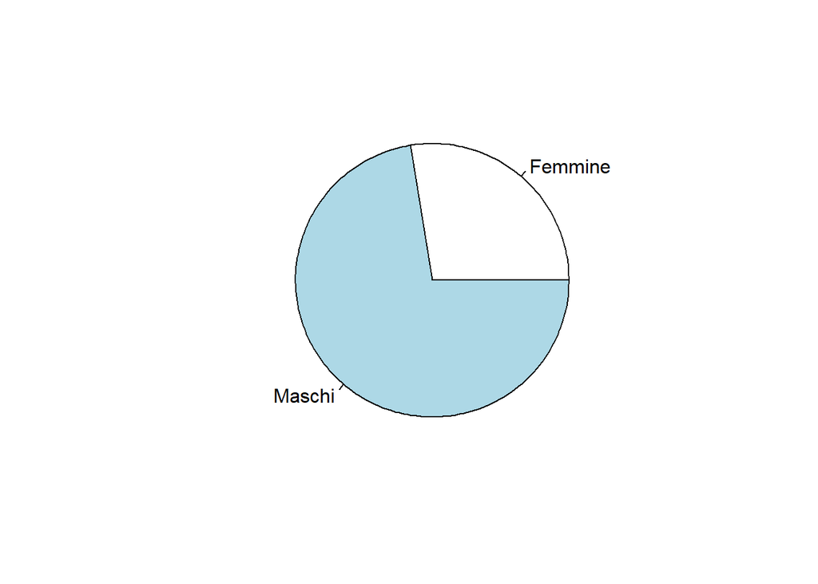

```r
pie(table(egypop23_gender))
```

- **Tidyverse**

Compute the relative frequency of males and females in 2023

```r
egypop23_gender <- milan_egypop %>%
  # filter by year
  filter(year == 2023) %>%
  # total number of inhabitants in 2023
  mutate(N = sum(inhab)) %>%
  # perform operations by gender (separately on males and females)
  group_by(gender) %>%
  # absolute and relative frequency by gender
  mutate(n = sum(inhab),
         f = n / N) %>%
  # select useful variables
  select(year, gender, n, f) %>%
  # keep only distinct rows
  distinct()
```

### Pie Chart

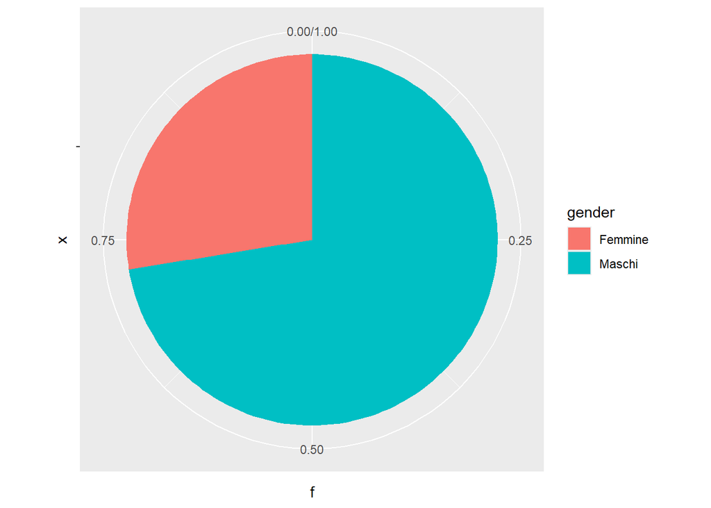

```r
ggplot(egypop23_gender, aes(x="", y=f, fill=gender)) +
  geom_bar(stat="identity", width=1) +
  coord_polar("y", start=0)
```

### Bar Plot

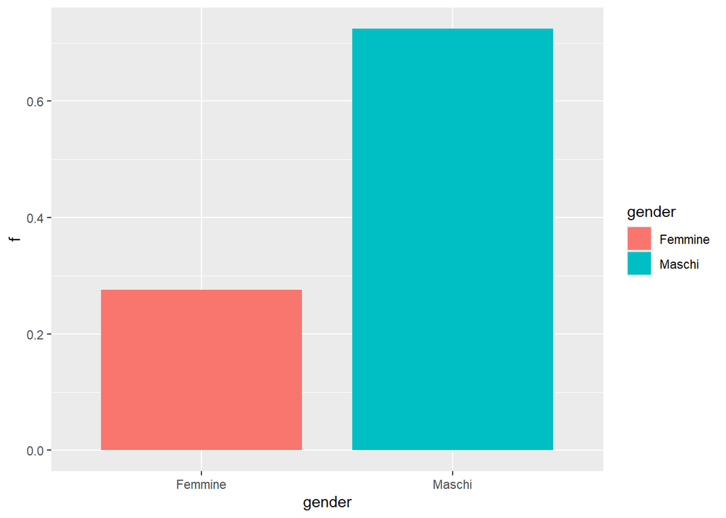

```r
ggplot(egypop23_gender, aes(x=gender, y=f, fill=gender)) +
  geom_col(width=.8)
```

Exercise 1: Compute the relative frequency distribution of Egyptians by age in Milan in 2023. Is it easy to do it in base-R?

## Example: Absolute and relative frequency distribution of Egyptians by year and gender in Milan

- **Tidyverse**

Compute the relative frequency of males and females across years

```r
egypop_gender <- milan_egypop %>%
  # total number of inhabitants by gender
  group_by(gender) %>%
  mutate(N = sum(inhab)) %>%
  # perform operations by gender and year
  group_by(gender, year) %>%
  # absolute frequency by gender
  mutate(n = sum(inhab),
         f = n / N) %>%
  # select useful variables
  select(year, gender, n, f) %>%
  # keep only distinct rows
  distinct()
```

### Bar Plot

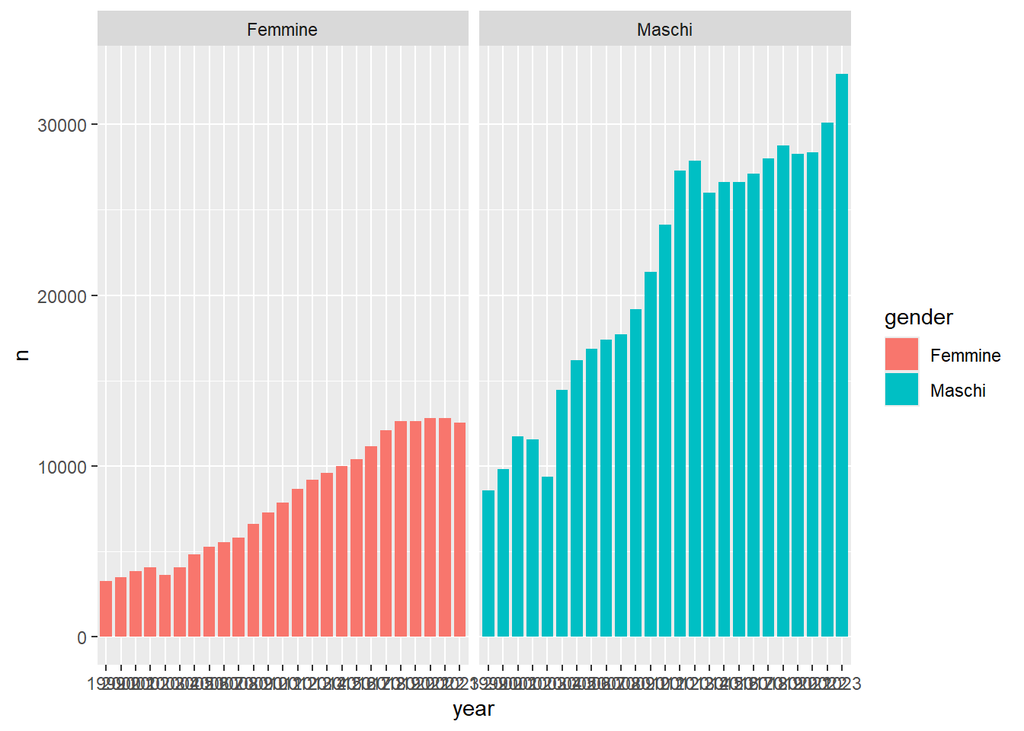

```r
ggplot(egypop_gender, aes(x=year, y=n, fill=gender)) +
  geom_col(width=.8) +
  facet_grid(cols = vars(gender))
```

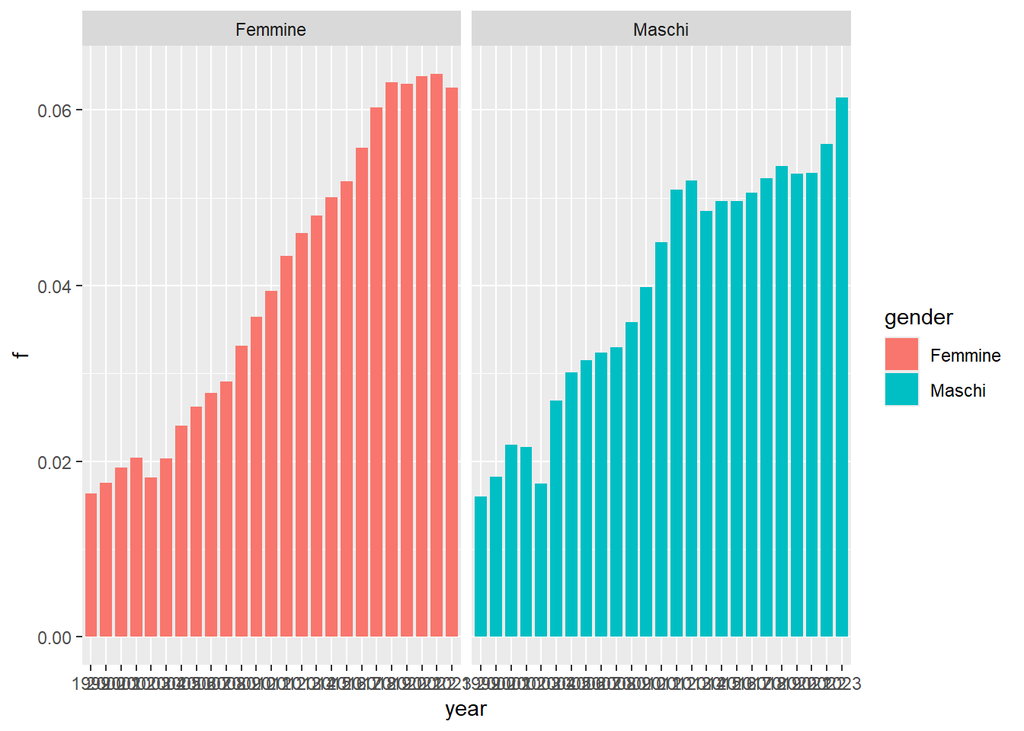

```r
ggplot(egypop_gender, aes(x=year, y=f, fill=gender)) +
  geom_col(width=.8) +
  facet_grid(cols = vars(gender))
```

### Trend plot

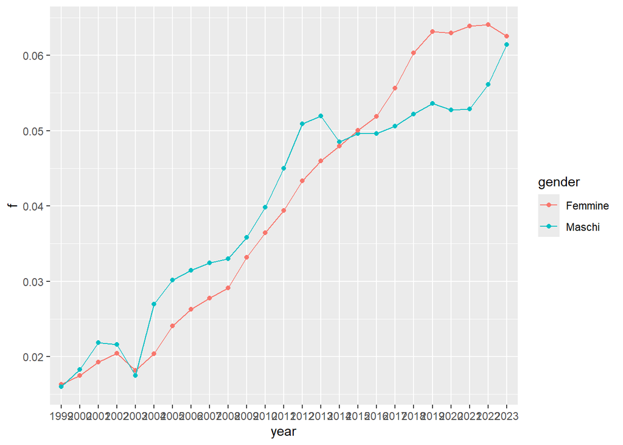

```r
ggplot(egypop_gender, aes(x=year, y=f, color=gender, group=gender)) +
  geom_point() +
  geom_line()
```

Execise 2: Compute the absolute and relative frequency distribution of Egyptians by age and gender in Milan

Exercise 3: Explore [ggplot2](https://rstudio.github.io/cheatsheets/html/data-visualization.html?_gl=1*j5gmuz*_ga*MjYyNDg5NzQ4LjE3MDI1NTA4OTI.*_ga_2C0WZ1JHG0*MTcxMTAwNzc5OS4xMi4wLjE3MTEwMDc3OTkuMC4wLjA.) cheatsheet and geom_hist() documentation.

Exercise 4: Load salary data: “practice/01-Descriptive/data/milan_sal.csv” How are salary data organized? How data need to be organized to develop a ggplot2 histogram?